# NYC/CHI Airbnb data analysis

Ray Pan yulinp3@illinois.edu & Patina Shi zhans5@illinois.edu

4/30/2021

# Introduction

People love traveling to metropolis, especially NYC and Chicago. Staying at Airbnb is popular since it is cheaper and safer while offering various travel experiences. We would like to perform a research on this due to the fact that sharing economy is a trend in the modern world and analysis of dataset like this would help us build background information for future researches. Here is some dataset from Airbnb open data about the reservation in NYC in 2019 and Chicago from 2017-2019. The two dataset each contains 15 columns. The Chicago dataset contains 6398 records and the NYCcontains 48896 records. Some important variables include room type, price, coordinates, and availability, etc.

# Methods

## Data

```r
# load packages
library(tidyverse)
library(dplyr)
library(readr)
library(ggpubr)
library(kableExtra)
```

```r
#import dataset
chi_airbnb <- read_csv("listings (1).csv")
nyc_airbnb <- read_csv("AB_NYC_2019 2.csv")
```

The original NYC airbnb dataset contains one more column than the CHI airbnb dataset and they all contain some NA values in some columns. We did some data cleaning to avoid the NA variables, we also checked the proportion of cleaned dataset comparing to original dataset, combined two separate dataset as one while avoiding the extra column, and print the descriptor portion of final cleaned dataset.

```
## [1] 0.8230421
```

```
## [1] 0.7939667
```

```
## tibble[,15] [44,086 x 15] (S3: tbl_df/tbl/data.frame)
##  $ id                            : num [1:44086] 2539 2595 3831 5022 5099 ...
##  $ name                          : chr [1:44086] "Clean & quiet apt home by the park" "Skylit Midtown Castle" "Cozy Entire Floor of Brownstone" "Entire Apt: Spacious Studio/Loft by central park" ...
##  $ host_id                       : num [1:44086] 2787 2845 4869 7192 7322 ...
##  $ host_name                     : chr [1:44086] "John" "Jennifer" "LisaRoxanne" "Laura" ...
##  $ neighbourhood                 : chr [1:44086] "Kensington" "Midtown" "Clinton Hill" "East Harlem" ...
##  $ latitude                      : num [1:44086] 40.6 40.8 40.7 40.8 40.7 ...
##  $ longitude                     : num [1:44086] -74 -74 -74 -73.9 -74 ...
##  $ room_type                     : chr [1:44086] "Private room" "Entire home/apt" "Entire home/apt" "Entire home/apt" ...
##  $ price                         : num [1:44086] 149 225 89 80 200 60 79 79 150 135 ...
##  $ minimum_nights                : num [1:44086] 1 1 1 10 3 45 2 2 1 5 ...
##  $ number_of_reviews             : num [1:44086] 9 45 270 9 74 49 430 118 160 53 ...
##  $ last_review                   : Date[1:44086], format: "2018-10-19" "2019-05-21" ...
##  $ reviews_per_month             : num [1:44086] 0.21 0.38 4.64 0.1 0.59 0.4 3.47 0.99 1.33 0.43 ...
##  $ calculated_host_listings_count: num [1:44086] 6 2 1 1 1 1 1 1 4 1 ...
##  $ availability_365              : num [1:44086] 365 355 194 0 129 0 220 0 188 6 ...
##  - attr(*, "na.action")= 'omit' Named int [1:10074] 3 20 27 37 39 194 205 261 266 268 ...
##   ..- attr(*, "names")= chr [1:10074] "3" "20" "27" "37" ...
```

## Modeling

We wanted to create a new variable based on the latitude and longitude variables, so we performed a data validation check and found out there are no coordinates misplaced.

```
## integer(0)
```

```
## integer(0)
```

We used the coordinates of Time Square, Central Park, Millennium Park and Willies Tower to find out the distance from each airbnb location to common attractions.

We wanted to find out whether proximity to popular attractions would affect other response variables such as number of people choosing to live here(reviews_per_month) and price, etc. A new variable named “distance2comattr” is created for convenience.

R-squared value for Review per month and distance:

```
## [1] 0.006323372
```

R-squared value for price and distance:

```
## [1] 0.01996096
```

The values of adjusted R-squared is low, which indicates there are barely any interaction between these variables. We could say that the distance to common attractions does not directly affect the Airbnb’s number of reviews per month(how many people chose to live here) or price.

To find out which host is the busiest and see why, we first tried to find out which apt got most reviews per month and list out its apartment type and several import information.

| id | name | host_id | host_name | neighbourhood | latitude | longitude | room_type | price | minimum_nights | number_of_reviews | last_review | reviews_per_month | calculated_host_listings_count | availability_365 | distance2comattr |
| --- | --- | --- | --- | --- | --- | --- | --- | --- | --- | --- | --- | --- | --- | --- | --- |
| 32678719 | Enjoy great views of the City in our Deluxe Room! | 244361589 | Row NYC | Theater District | 40.75918 | -73.98801 | Private room | 100 | 1 | 156 | 2019-07-07 | 58.5 | 9 | 299 | 1.109428 |

```
##
## Private room
##            6
```

```
##        min        max       mean   distance
## 100.000000 249.000000 141.333333   1.138784
```

**Similarities and Difference between NYC and CHI**

To find out the similarities and differences between NYC and CHI airbnb, we listed out the summary of price in CHI and NYC, barplot of distance to common attractions, room type, and price based on different room type.

```
##    Min. 1st Qu.  Median    Mean 3rd Qu.    Max.
##    10.0    62.0    95.0   145.3   150.0 10000.0
```

```
##    Min. 1st Qu.  Median    Mean 3rd Qu.    Max.
##     0.0    69.0   101.0   142.3   170.0 10000.0
```

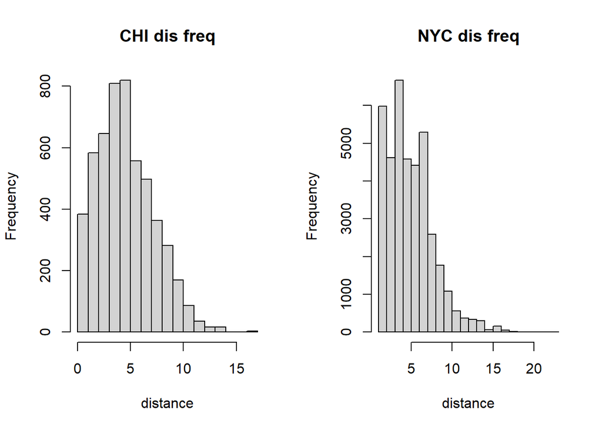

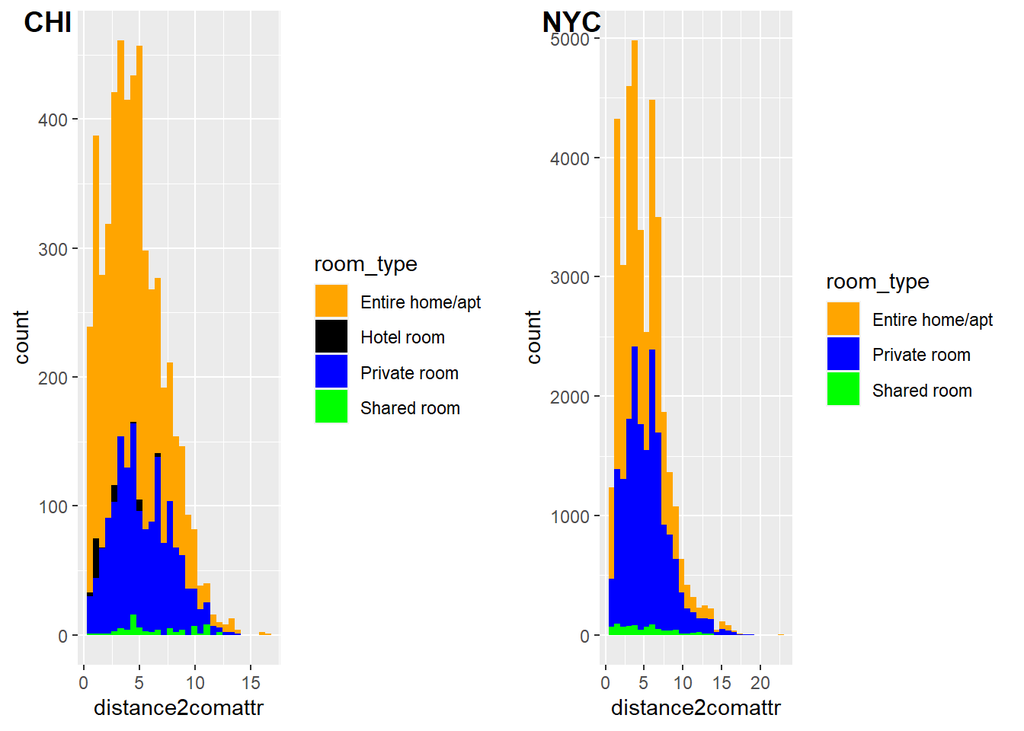

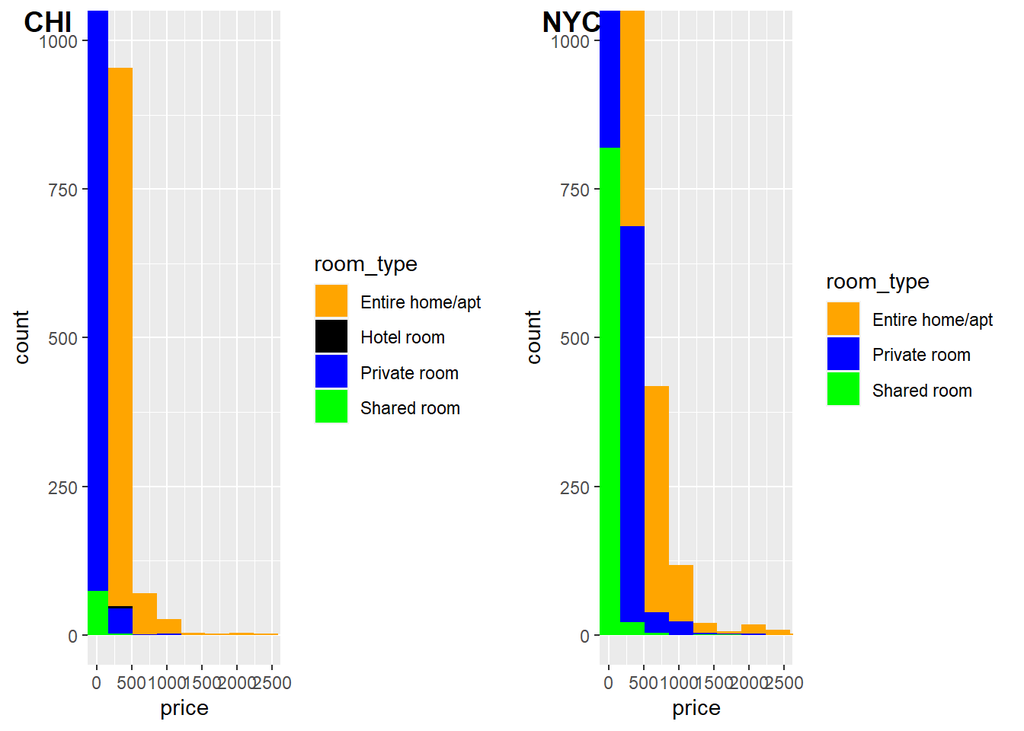

# Results

The values of adjusted R-squared are low, which indicates there are barely any interaction between distance, number of reviews per month, and price. We could conclude that the distance to common attractions does not directly affect the Airbnb’s number of reviews per month(how many people chose to live here) or price.

We found “Row NYC” is the busiest host. “Row NYC” holds 6 places in NYC and all of them are private room. “Row NYC”’s places average only 1.14 miles from the common attractions in NYC and priced at around 141 per day. We conclude that high performance cost ratio is what makes “Row NYC” popular in NYC.

# Appendix

```
## Williamsburg
##         3163
```

```
##  [1] 10000 10000 10000  9999  9999  9999  9999  9999  9999  9999  8500  8000
## [13]  7500  6000  5100  5000  5000  5000  5000  5000
```

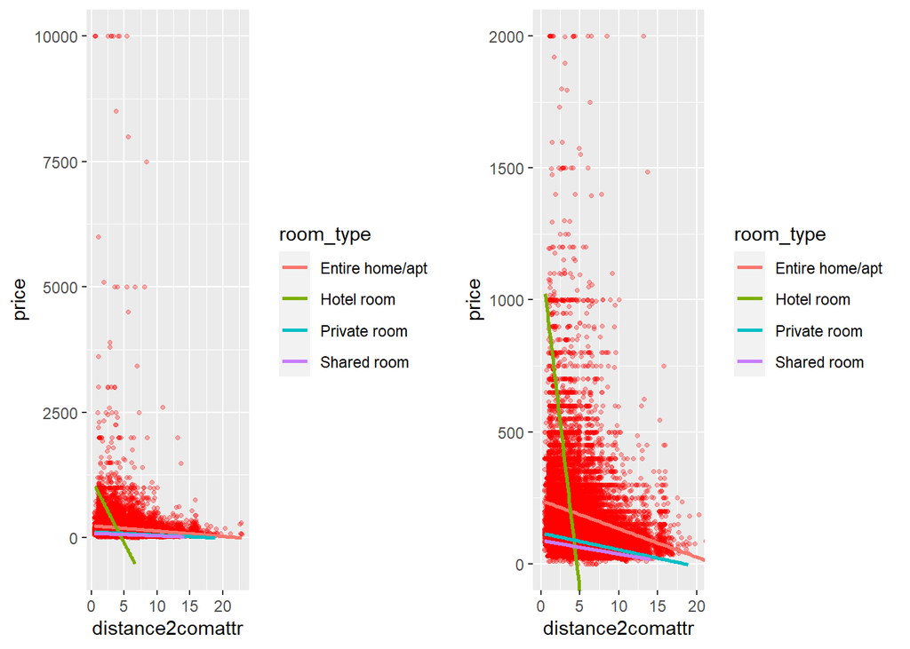

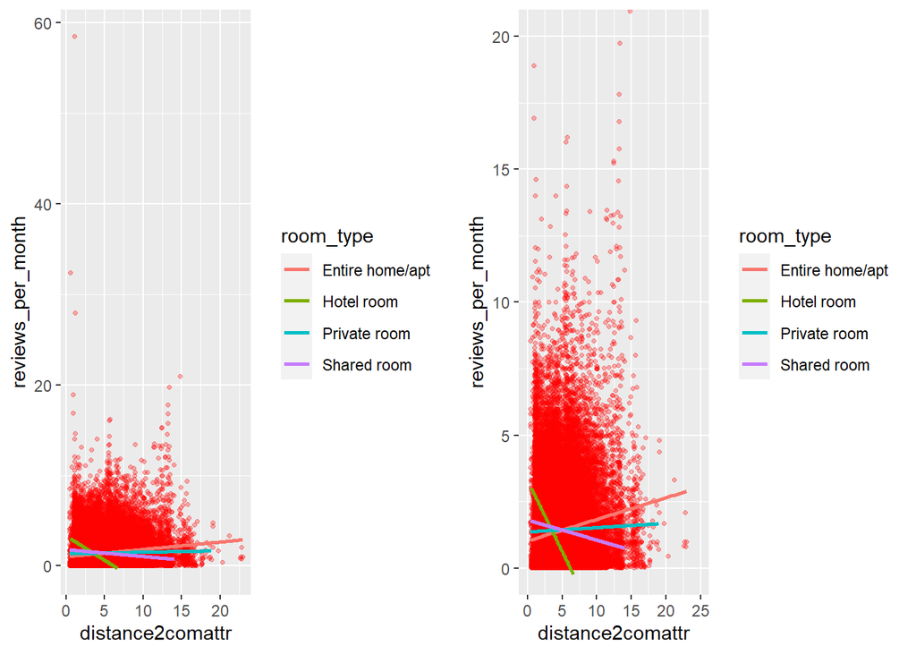